# DATS 6101 - Wine Chemical Properties

```r
round(pR2(model_std),2) # McFadden Pseudo-R2 is above 0.2
```

```
##      llh  llhNull       G2 McFadden     r2ML     r2CU
## -2553.77 -3219.82  1332.10     0.21     0.19     0.29
```

```r
prob <- predict(model, type = c("response"))
h <- roc(quality.dum~prob, data=wine_df)
h # Area under the curve: 0.8104
```

```
##
## Call:
## roc.formula(formula = quality.dum ~ prob, data = wine_df)
##
## Data: prob in 5220 controls (quality.dum 0) < 1277 cases (quality.dum 1).
## Area under the curve: 0.809
```

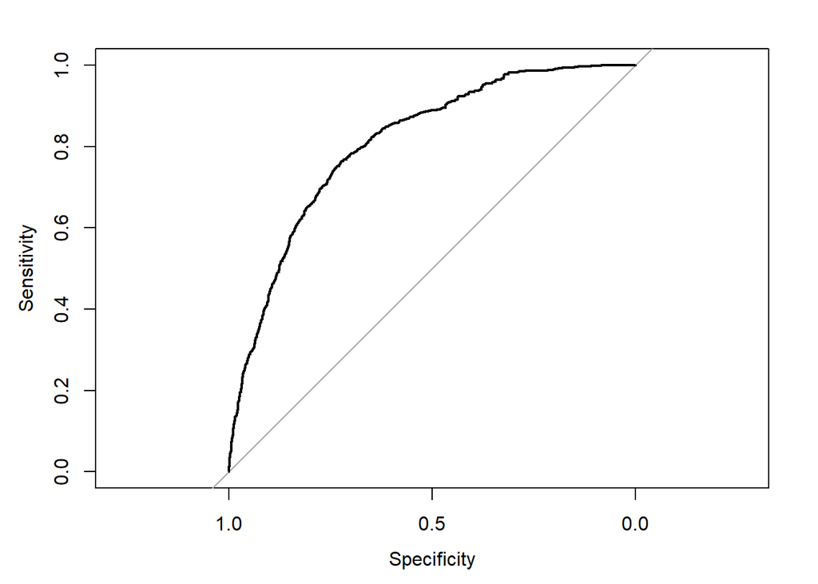

```r
plot(h)
```

```r
### Train v Test ###
View(wine_df)
wine_df_random <- wine_df[sample(1:nrow(wine_df)), ]
View(wine_df_random)
train <- wine_df_random[1:3248, ]
test <- wine_df_random[3249:6497, ]
train.model <- glm(quality.dum~fixed.acidity + volatile.acidity + residual.sugar +
                   chlorides + pH + total.sulfur.dioxide + alcohol +
                   citric.acid*type + sulphates*type + total.sulfur.dioxide*type,
                   family = binomial(link = "logit"), data = train)
summary(train.model)
```

```
##
## Call:
## glm(formula = quality.dum ~ fixed.acidity + volatile.acidity +
##     residual.sugar + chlorides + pH + total.sulfur.dioxide +
##     alcohol + citric.acid * type + sulphates * type + total.sulfur.dioxide *
##     type, family = binomial(link = "logit"), data = train)
##
## Deviance Residuals:
##     Min       1Q   Median       3Q      Max
## -2.0908  -0.6355  -0.3784  -0.1274   3.2449
##
## Coefficients:
##                             Estimate Std. Error z value Pr(>|z|)
## (Intercept)               -1.459e+01  1.656e+00  -8.815  < 2e-16 ***
## fixed.acidity              6.228e-02  6.181e-02   1.008 0.313667
## volatile.acidity          -3.271e+00  5.479e-01  -5.969 2.38e-09 ***
## residual.sugar             6.479e-02  1.399e-02   4.631 3.65e-06 ***
## chlorides                 -1.575e+01  3.962e+00  -3.977 6.99e-05 ***
## pH                         9.783e-01  3.808e-01   2.569 0.010190 *
## total.sulfur.dioxide       4.784e-04  1.594e-03   0.300 0.764100
## alcohol                    9.662e-01  5.632e-02  17.156  < 2e-16 ***
## citric.acid               -1.607e-01  5.796e-01  -0.277 0.781625
## type                      -1.992e+00  7.399e-01  -2.693 0.007084 **
## sulphates                  1.003e+00  4.457e-01   2.251 0.024389 *
## citric.acid:type           1.227e+00  8.894e-01   1.379 0.167744
## type:sulphates             3.423e+00  9.742e-01   3.514 0.000441 ***
## total.sulfur.dioxide:type -8.582e-03  4.391e-03  -1.954 0.050664 .
## ---
## Signif. codes:  0 '***' 0.001 '**' 0.01 '*' 0.05 '.' 0.1 ' ' 1
##
## (Dispersion parameter for binomial family taken to be 1)
##
##     Null deviance: 3301.0  on 3247  degrees of freedom
## Residual deviance: 2573.1  on 3234  degrees of freedom
## AIC: 2601.1
##
## Number of Fisher Scoring iterations: 6
```

```r
library(ROCR)
```

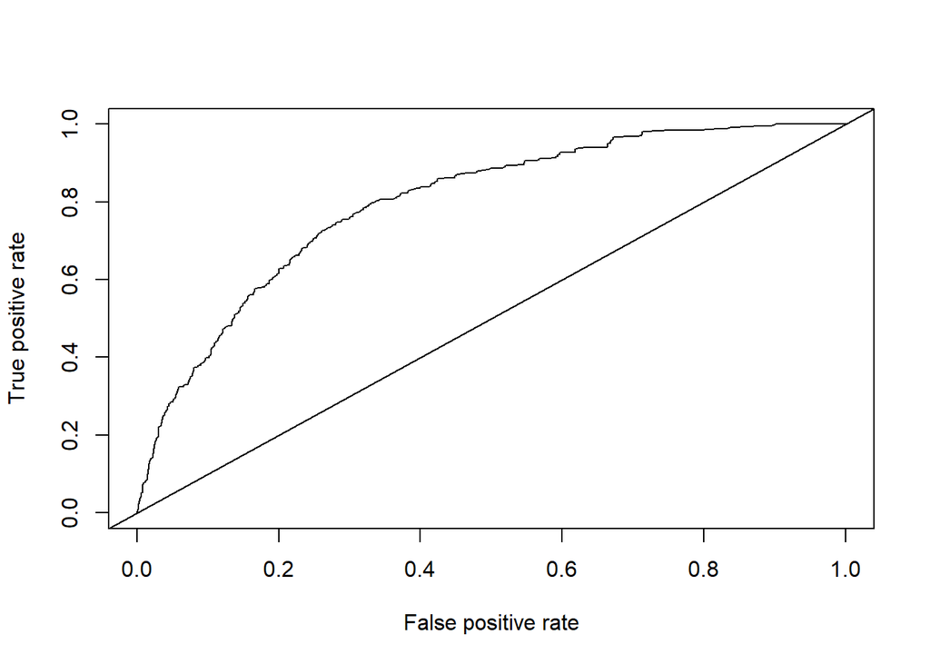

```r
pred.model <- predict.glm(train.model, test, type='response')
newpred <- prediction(pred.model, test$quality.dum)
newpred.performance <- performance(newpred, measure = "tpr",x.measure = "fpr")
plot(newpred.performance)
abline(a=0, b= 1)
```

```r
AUC <- performance(newpred, measure = "auc")
AUC # Correctly predicted 82%
```

```
## An object of class "performance"
## Slot "x.name":
## [1] "None"
##
## Slot "y.name":
## [1] "Area under the ROC curve"
##
## Slot "alpha.name":
## [1] "none"
##
## Slot "x.values":
## list()
##
## Slot "y.values":
## [[1]]
## [1] 0.7975164
##
##
## Slot "alpha.values":
## list()
```

## Odds Ratios

Need to manually create odds ratio for interaction terms. The log odds are not very useful as the scales are not inuitive (unless perhaps you are a chemist). Instead, we will illustrate change using predicted probabilities.

```r
### Create Log odds ###
alcohol <- summary(model)$coefficients[8]
residual.sugar <- summary(model)$coefficients[4]
white.citric.acid.coef <- summary(model)$coefficients[9]
red.citric.acid.coef <- summary(model)$coefficients[9]+summary(model)$coefficients[12]
white.sulphates.coef <- summary(model)$coefficients[11]
red.sulphates.coef <- summary(model)$coefficients[11]+summary(model)$coefficients[13]
white.total.sulfur.dioxide.coef <- summary(model)$coefficients[7]
red.total.sulfur.dioxide.coef <- summary(model)$coefficients[7]+summary(model)$coefficients[14]

### Log odds
paste("Alcohol", round(exp(alcohol),2))
```

```
## [1] "Alcohol 2.45"
```

```r
paste("Residual Sugar", round(residual.sugar,2))
```

```
## [1] "Residual Sugar 0.06"
```

```r
paste("White wine: Citric Acid", round(exp(white.citric.acid.coef),2))
```

```
## [1] "White wine: Citric Acid 0.37"
```

```r
paste("Red wine: Citric Acid", round(exp(red.citric.acid.coef),2))
```

```
## [1] "Red wine: Citric Acid 2.64"
```

```r
paste("White wine: Sulphates", round(exp(white.sulphates.coef),2))
```

```
## [1] "White wine: Sulphates 3.72"
```

```r
paste("Red wine: Sulphates", round(exp(red.sulphates.coef),2))
```

```
## [1] "Red wine: Sulphates 31.93"
```

```r
paste("White wine: SO2", round(exp(white.total.sulfur.dioxide.coef),2))
```

```
## [1] "White wine: SO2 1"
```

```r
paste("Red wine: SO2", round(exp(red.total.sulfur.dioxide.coef),2))
```

```
## [1] "Red wine: SO2 0.99"
```

## Predicted Probabilities

Generating predictions as variables move from their 20th percentile to their 80th percentile. While such a change in variable is uncommon, it is much more likely than a variable mvoing from their minimum to their maximum.

Predictions 1) Alcohol: predict quality of wine as alcohol moves from 9.4% to 11.5% alcohol content and everything else, including type of wine, rest at their mean. 2) Residual Sugar: predict quality of wine as sugar moves from 1.7 g/dm3 to 9.6 g/dm3 and everything else, including type of wine, rest at their mean. 3) Red Wine Interactions: predict quality of red wine as SO2 moves from 165.0 to 62.2 mg/dm3 and Sulphates move from 0.41 g(potassium sulphate)/dm3 to 0.63 g(potassium sulphate)/dm3 and everything else, except type of wine which is red, rest at their mean. We also predict the same relationship with white wine to show that it has a smaller impact. 4) White Wine Interactions: predict quality of white wine as citric acid moves from 0.23 to 0.42 mg/dm3 and everything else, except type of wine which is white, rest at their mean. We also predict the same relationship with red wine to show that it has a smaller impact. 5) Top Six for red wine: predict quality of red wine based on high alcohol, sugar, and sulphates, and low total SO2, Chlorides, and Volatile Acidity, with the rest at its mean.

We created predicted probabilities that show that as alcohol content moves from its 20th percentile of 9.4% to its 80th percentile of 11.5%, the likelihood of that wine resulting in high quality wine moves from 0.04 to 0.21. For residual sugar, a similar change increases the likelihood from 0.08 to 0.12. The red wine interactions (sulphates and total SO2) also make large increases in probability, but the white wine interactions (citric acid) do not make as much change. Using the top six variables at their 80th percentile (or 20th percentile if they are negative), we can reach a predicted probability as high as 0.5. In other words, it’s extremely difficult to make high quality wine more likely than low quality wine, based on how we defined high quality wine.

```r
### Predicted Probabilities ###
model <- glm(quality.dum~fixed.acidity + volatile.acidity + residual.sugar +
               chlorides + pH + total.sulfur.dioxide + alcohol +
               citric.acid*type + sulphates*type + total.sulfur.dioxide*type,
             family = binomial(link = "logit"), data = wine_df)
summary(model)
```

```
##
## Call:
## glm(formula = quality.dum ~ fixed.acidity + volatile.acidity +
##     residual.sugar + chlorides + pH + total.sulfur.dioxide +
##     alcohol + citric.acid * type + sulphates * type + total.sulfur.dioxide *
##     type, family = binomial(link = "logit"), data = wine_df)
##
## Deviance Residuals:
##     Min       1Q   Median       3Q      Max
## -2.3865  -0.6408  -0.3825  -0.1345   3.2357
##
## Coefficients:
##                             Estimate Std. Error z value Pr(>|z|)
## (Intercept)               -1.358e+01  1.164e+00 -11.669  < 2e-16 ***
## fixed.acidity              6.572e-02  4.385e-02   1.499 0.133899
## volatile.acidity          -3.911e+00  3.931e-01  -9.949  < 2e-16 ***
## residual.sugar             5.862e-02  9.379e-03   6.250 4.10e-10 ***
## chlorides                 -1.349e+01  2.712e+00  -4.972 6.62e-07 ***
## pH                         9.693e-01  2.710e-01   3.576 0.000349 ***
## total.sulfur.dioxide      -1.993e-05  1.114e-03  -0.018 0.985728
## alcohol                    8.958e-01  3.861e-02  23.199  < 2e-16 ***
## citric.acid               -9.909e-01  3.891e-01  -2.547 0.010878 *
## type                      -1.210e+00  4.772e-01  -2.537 0.011193 *
## sulphates                  1.313e+00  3.190e-01   4.116 3.86e-05 ***
## citric.acid:type           1.963e+00  6.413e-01   3.060 0.002210 **
## type:sulphates             2.151e+00  6.108e-01   3.521 0.000430 ***
## total.sulfur.dioxide:type -1.375e-02  3.714e-03  -3.702 0.000214 ***
## ---
## Signif. codes:  0 '***' 0.001 '**' 0.01 '*' 0.05 '.' 0.1 ' ' 1
##
## (Dispersion parameter for binomial family taken to be 1)
##
##     Null deviance: 6439.6  on 6496  degrees of freedom
## Residual deviance: 5107.5  on 6483  degrees of freedom
## AIC: 5135.5
##
## Number of Fisher Scoring iterations: 6
```

```r
### Alcohol ###
quantile(wine_df$alcohol, c(.2, .8))
```

```
##  20%  80%
##  9.4 11.5
```

```r
# High Alcohol
highalcohol.pp <- data.frame(type=mean(wine_df$type), alcohol=quantile(wine_df$alcohol, c(.8)),
                             total.sulfur.dioxide=mean(wine_df$total.sulfur.dioxide),
                             chlorides=mean(wine_df$chlorides), fixed.acidity=mean(wine_df$fixed.acidity),
                             volatile.acidity=mean(wine_df$volatile.acidity),
                             residual.sugar=mean(wine_df$residual.sugar),
                             free.sulfur.dioxide=mean(wine_df$free.sulfur.dioxide),
                             total.sulfur.dioxide=mean(wine_df$total.sulfur.dioxide), pH=mean(wine_df$pH),
                             sulphates=mean(wine_df$sulphates), citric.acid=mean(wine_df$citric.acid))
highalcohol.pp.pred <- predict(model, highalcohol.pp, type='response')
# Low Alcohol
lowalcohol.pp <- data.frame(type=mean(wine_df$type), alcohol=quantile(wine_df$alcohol, c(.2)),
                            total.sulfur.dioxide=mean(wine_df$total.sulfur.dioxide),
                            chlorides=mean(wine_df$chlorides), fixed.acidity=mean(wine_df$fixed.acidity),
                            volatile.acidity=mean(wine_df$volatile.acidity),
                            residual.sugar=mean(wine_df$residual.sugar),
                            free.sulfur.dioxide=mean(wine_df$free.sulfur.dioxide),
                            total.sulfur.dioxide=mean(wine_df$total.sulfur.dioxide), pH=mean(wine_df$pH),
                            sulphates=mean(wine_df$sulphates), citric.acid=mean(wine_df$citric.acid))
lowalcohol.pp.pred <- predict(model, lowalcohol.pp, type='response')

paste("Wine with the max alcohol: ", round(highalcohol.pp.pred*100,0))
```

```
## [1] "Wine with the max alcohol:  21"
```

```r
paste("Wine with the min alcohol: ", round(lowalcohol.pp.pred*100,0))
```

```
## [1] "Wine with the min alcohol:  4"
```

```r
### Residual Sugar ###
quantile(wine_df$residual.sugar, c(.2, .8))
```

```
## 20% 80%
## 1.7 9.6
```

```r
# High sugar
highsugar.pp <- data.frame(type=mean(wine_df$type), residual.sugar=quantile(wine_df$residual.sugar, c(.8)),
                           alcohol=mean(wine_df$alcohol), total.sulfur.dioxide=mean(wine_df$total.sulfur.dioxide),
                           chlorides=mean(wine_df$chlorides), fixed.acidity=mean(wine_df$fixed.acidity),
                           volatile.acidity=mean(wine_df$volatile.acidity),
                           residual.sugar=mean(wine_df$residual.sugar),
                           free.sulfur.dioxide=mean(wine_df$free.sulfur.dioxide),
                           total.sulfur.dioxide=mean(wine_df$total.sulfur.dioxide), pH=mean(wine_df$pH),
                           sulphates=mean(wine_df$sulphates), citric.acid=mean(wine_df$citric.acid))
highsugar.pp.pred <- predict(model, highsugar.pp, type='response')
# Low sugar
lowsugar.pp <- data.frame(type=mean(wine_df$type), residual.sugar=quantile(wine_df$residual.sugar, c(.2)),
                          alcohol=mean(wine_df$alcohol), total.sulfur.dioxide=mean(wine_df$total.sulfur.dioxide),
                          chlorides=mean(wine_df$chlorides), fixed.acidity=mean(wine_df$fixed.acidity),
                          volatile.acidity=mean(wine_df$volatile.acidity),
                          free.sulfur.dioxide=mean(wine_df$free.sulfur.dioxide),
                          total.sulfur.dioxide=mean(wine_df$total.sulfur.dioxide), pH=mean(wine_df$pH),
                          sulphates=mean(wine_df$sulphates), citric.acid=mean(wine_df$citric.acid))
lowsugar.pp.pred <- predict(model, lowsugar.pp, type='response')

paste("Wine with the max alcohol: ", round(highsugar.pp.pred*100,0))
```

```
## [1] "Wine with the max alcohol:  12"
```

```r
paste("Wine with the min alcohol: ", round(lowsugar.pp.pred*100,0))
```

```
## [1] "Wine with the min alcohol:  8"
```

```r
### Interactions ###
### Red Interactions ###
quantile(wine_df$total.sulfur.dioxide, c(.2, .8))
```

```
##   20%   80%
##  62.2 165.0
```

```r
quantile(wine_df$sulphates, c(.2, .8))
```

```
##  20%  80%
## 0.41 0.63
```

```r
# Low SO2 and High Sulphates
red.bestred.pp <- data.frame(type=1, total.sulfur.dioxide=quantile(wine_df$total.sulfur.dioxide, c(.2)),
                             sulphates=quantile(wine_df$sulphates, c(.8)),
                             chlorides=mean(wine_df$chlorides), fixed.acidity=mean(wine_df$fixed.acidity),
                             volatile.acidity=mean(wine_df$volatile.acidity),
                             residual.sugar=mean(wine_df$residual.sugar),
                             free.sulfur.dioxide=mean(wine_df$free.sulfur.dioxide),
                             pH=mean(wine_df$pH), alcohol=mean(wine_df$alcohol), citric.acid=mean(wine_df$citric.acid))
red.bestred.pp.pred <- predict(model, red.bestred.pp, type='response')
# High SO2 and Low Sulphates
red.worstred.pp <- data.frame(type=1, total.sulfur.dioxide=quantile(wine_df$total.sulfur.dioxide, c(.8)),
                              sulphates=quantile(wine_df$sulphates, c(.2)),
                              chlorides=mean(wine_df$chlorides), fixed.acidity=mean(wine_df$fixed.acidity),
                              volatile.acidity=mean(wine_df$volatile.acidity),
                              residual.sugar=mean(wine_df$residual.sugar),
                              free.sulfur.dioxide=mean(wine_df$free.sulfur.dioxide),
                              pH=mean(wine_df$pH), alcohol=mean(wine_df$alcohol), citric.acid=mean(wine_df$citric.acid))
red.worstred.pp.pred <- predict(model, red.worstred.pp, type='response')

paste("Red Wine with the max sulphates and min SO2: ", round(red.bestred.pp.pred*100,0))
```

```
## [1] "Red Wine with the max sulphates and min SO2:  13"
```

```r
paste("Red Wine with the min sulphates and max SO2: ", round(red.worstred.pp.pred*100,0))
```

```
## [1] "Red Wine with the min sulphates and max SO2:  2"
```

```r
# Compare results to the white wine equivalent
# Low SO2 and High Sulphates
white.bestwhite.pp <- data.frame(type=0, total.sulfur.dioxide=quantile(wine_df$total.sulfur.dioxide, c(.2)),
                                 sulphates=quantile(wine_df$sulphates, c(.8)),
                                 chlorides=mean(wine_df$chlorides), fixed.acidity=mean(wine_df$fixed.acidity),
                                 volatile.acidity=mean(wine_df$volatile.acidity),
                                 residual.sugar=mean(wine_df$residual.sugar),
                                 free.sulfur.dioxide=mean(wine_df$free.sulfur.dioxide),
                                 pH=mean(wine_df$pH), alcohol=mean(wine_df$alcohol), citric.acid=mean(wine_df$citric.acid))
white.bestwhite.pp.pred <- predict(model, white.bestwhite.pp, type='response')
# High SO2 and Low Sulphates
white.worstwhite.pp <- data.frame(type=0, total.sulfur.dioxide=quantile(wine_df$total.sulfur.dioxide, c(.8)),
                                  sulphates=quantile(wine_df$sulphates, c(.2)),
                                  chlorides=mean(wine_df$chlorides), fixed.acidity=mean(wine_df$fixed.acidity),
                                  volatile.acidity=mean(wine_df$volatile.acidity),
                                  residual.sugar=mean(wine_df$residual.sugar),
                                  free.sulfur.dioxide=mean(wine_df$free.sulfur.dioxide),
                                  pH=mean(wine_df$pH), alcohol=mean(wine_df$alcohol),
                                  citric.acid=mean(wine_df$citric.acid))
white.worstwhite.pp.pred <- predict(model, white.worstwhite.pp, type='response')

paste("White Wine with the max sulphates and min SO2: ", round(white.bestwhite.pp.pred*100,0))
```

```
## [1] "White Wine with the max sulphates and min SO2:  14"
```

```r
paste("White Wine with the min sulphates and max SO2: ", round(white.worstwhite.pp.pred*100,0))
```

```
## [1] "White Wine with the min sulphates and max SO2:  11"
```

```r
### White Interactions ###
quantile(wine_df$citric.acid, c(.2, .8))
```

```
##  20%  80%
## 0.23 0.42
```

```r
# Low Citric Acid
white.bestwhite.pp <- data.frame(type=0, citric.acid=quantile(wine_df$citric.acid, c(.2)),
                                 total.sulfur.dioxide=mean(wine_df$total.sulfur.dioxide),
                                 sulphates=mean(wine_df$sulphates),
                                 chlorides=mean(wine_df$chlorides), fixed.acidity=mean(wine_df$fixed.acidity),
                                 volatile.acidity=mean(wine_df$volatile.acidity),
                                 residual.sugar=mean(wine_df$residual.sugar),
                                 free.sulfur.dioxide=mean(wine_df$free.sulfur.dioxide),
                                 pH=mean(wine_df$pH), alcohol=mean(wine_df$alcohol))
white.bestwhite.pp.pred <- predict(model, white.bestwhite.pp, type='response')
# High Citric Acid
white.worstwhite.pp <- data.frame(type=0, citric.acid=quantile(wine_df$citric.acid, c(.8)),
                                  total.sulfur.dioxide=mean(wine_df$total.sulfur.dioxide),
                                  sulphates=mean(wine_df$sulphates),
                                  chlorides=mean(wine_df$chlorides), fixed.acidity=mean(wine_df$fixed.acidity),
                                  volatile.acidity=mean(wine_df$volatile.acidity),
                                  residual.sugar=mean(wine_df$residual.sugar),
                                  free.sulfur.dioxide=mean(wine_df$free.sulfur.dioxide),
                                  pH=mean(wine_df$pH), alcohol=mean(wine_df$alcohol))
white.worstwhite.pp.pred <- predict(model, white.worstwhite.pp, type='response')

paste("White Wine with the min Citric Acid: ", round(white.bestwhite.pp.pred*100,0))
```

```
## [1] "White Wine with the min Citric Acid:  13"
```

```r
paste("White Wine with the max Citric Acid: ", round(white.worstwhite.pp.pred*100,0))
```

```
## [1] "White Wine with the max Citric Acid:  11"
```

```r
# Red Wine equivalent
# Low Citric Acid
red.bestwhite.pp <- data.frame(type=1, citric.acid=quantile(wine_df$citric.acid, c(.2)),
                               total.sulfur.dioxide=mean(wine_df$total.sulfur.dioxide), sulphates=mean(wine_df$sulphates),
                               chlorides=mean(wine_df$chlorides), fixed.acidity=mean(wine_df$fixed.acidity),
                               volatile.acidity=mean(wine_df$volatile.acidity),
                               residual.sugar=mean(wine_df$residual.sugar),
                               free.sulfur.dioxide=mean(wine_df$free.sulfur.dioxide),
                               pH=mean(wine_df$pH), alcohol=mean(wine_df$alcohol))
red.bestwhite.pp.pred <- predict(model, red.bestwhite.pp, type='response')
# High Citric Acid
red.worstwhite.pp <- data.frame(type=1, citric.acid=quantile(wine_df$citric.acid, c(.8)),
                                total.sulfur.dioxide=mean(wine_df$total.sulfur.dioxide), sulphates=mean(wine_df$sulphates),
                                chlorides=mean(wine_df$chlorides), fixed.acidity=mean(wine_df$fixed.acidity),
                                volatile.acidity=mean(wine_df$volatile.acidity),
                                residual.sugar=mean(wine_df$residual.sugar),
                                free.sulfur.dioxide=mean(wine_df$free.sulfur.dioxide),
                                pH=mean(wine_df$pH), alcohol=mean(wine_df$alcohol))
red.worstwhite.pp.pred <- predict(model, red.worstwhite.pp, type='response')

paste("White Wine with the min Citric Acid: ", round(red.bestwhite.pp.pred*100,0))
```

```
## [1] "White Wine with the min Citric Acid:  4"
```

```r
paste("White Wine with the max Citric Acid: ", round(red.worstwhite.pp.pred*100,0))
```

```
## [1] "White Wine with the max Citric Acid:  5"
```

```r
### Best wine ###
# High alcohol, sugar, and sulphates, and low total SO2, Chlorides, and Volatile Acidity, and red wine
bestwine.pp <- data.frame(type=1, alcohol=quantile(wine_df$alcohol, c(.8)),
                          total.sulfur.dioxide=quantile(wine_df$total.sulfur.dioxide, c(.2)),
                          chlorides=quantile(wine_df$chlorides, c(.2)), fixed.acidity=mean(wine_df$fixed.acidity),
                          volatile.acidity=quantile(wine_df$volatile.acidity, c(.2)),
                          residual.sugar=quantile(wine_df$residual.sugar, c(.8)),
                          free.sulfur.dioxide=mean(wine_df$free.sulfur.dioxide),
                          total.sulfur.dioxide=mean(wine_df$total.sulfur.dioxide), pH=mean(wine_df$pH),
                          sulphates=quantile(wine_df$sulphates, c(.8)), citric.acid=mean(wine_df$citric.acid))
bestwine.pp.pred <- predict(model, bestwine.pp, type='response')
# Low alcohol, sugar, and sulphates, and high total SO2, Chlorides, and Volatile Acidity, and red wine
worsewine.pp <- data.frame(type=1, alcohol=quantile(wine_df$alcohol, c(.2)),
                           total.sulfur.dioxide=quantile(wine_df$total.sulfur.dioxide, c(.8)),
                           chlorides=quantile(wine_df$chlorides, c(.8)), fixed.acidity=mean(wine_df$fixed.acidity),
                           volatile.acidity=quantile(wine_df$volatile.acidity, c(.8)),
                           residual.sugar=quantile(wine_df$residual.sugar, c(.2)),
                           free.sulfur.dioxide=mean(wine_df$free.sulfur.dioxide),
                           total.sulfur.dioxide=mean(wine_df$total.sulfur.dioxide), pH=mean(wine_df$pH),
                           sulphates=quantile(wine_df$sulphates, c(.2)), citric.acid=mean(wine_df$citric.acid))
worsewine.pp.pred <- predict(model, worsewine.pp, type='response')

paste("Red wine with the top six best traits: ", round(bestwine.pp.pred*100,0))
```

```
## [1] "Red wine with the top six best traits:  50"
```

```r
paste("Red wine with the top six worst traits: ", round(worsewine.pp.pred*100,2))
```

```
## [1] "Red wine with the top six worst traits:  0.26"
```